# ggplot2 (Swirl)

#### 3.2.3 facet_grid()

Note that this is the same type of formula used in the calls to qplot.

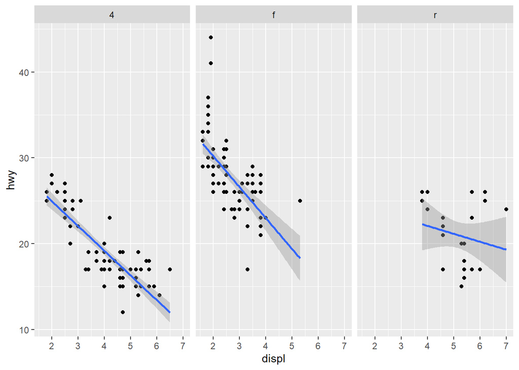

```r
g+geom_point()+geom_smooth(method="lm")+facet_grid(.~drv)
```

##### Explanation:

- Notice how each panel is labeled with the appropriate factor.
- All the data associated with 4-wheel drive cars is in the leftmost panel,
- front-wheel drive data is shown in the middle panel, and
- rear-wheel drive data in the rightmost.

#### 3.2.4 xlab(), ylab(), and ggtitle()

- So far you’ve just used the default labels that ggplot provides.
- You can add your own annotation using functions such as xlab(), ylab(), and ggtitle().
- In addition, the function labs() is more general and can be used to label either or both axes as well as provide a title.

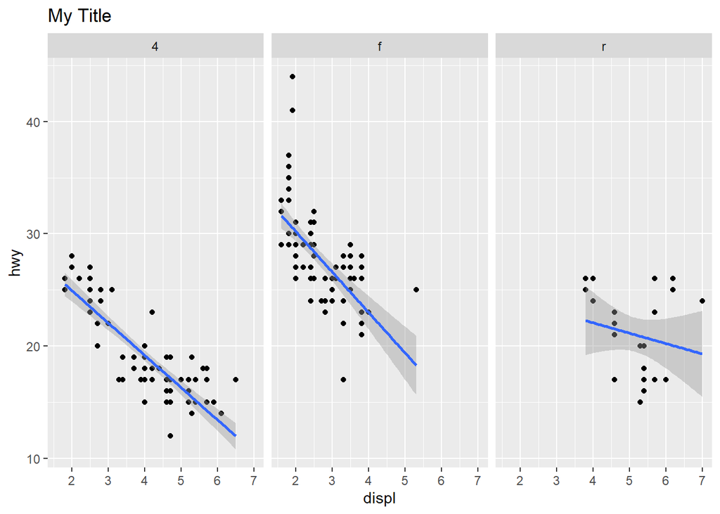

```r
g+geom_point()+geom_smooth(method="lm")+facet_grid(.~drv)+ggtitle("My Title")
```

### 3.3 Argument Customizing

#### 3.3.1 Customizing aesthetics (When arguments are Constant)

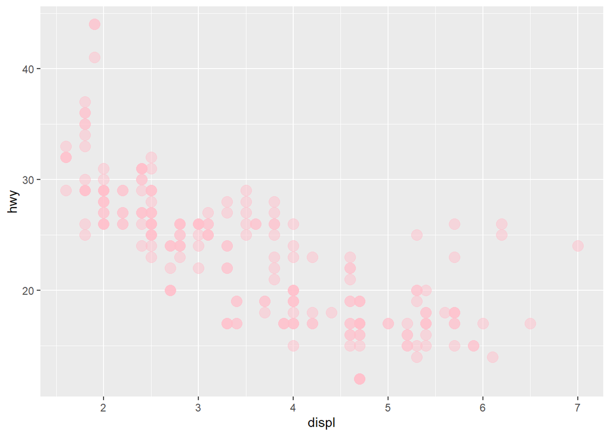

```r
g+geom_point(color = "pink", size = 4, alpha = 0.5)
```

##### Explanation:

**Notice that all the arguments are set equal to constants.**

- Notice the different shades of pink? That’s the result of the alpha aesthetic which you set to 0.5
- This aesthetic tells ggplot how transparent the points should be.
- Darker circles indicate values hit by multiple data points.

#### 3.3.2 Customizing aesthetics (When argument is data dependent)

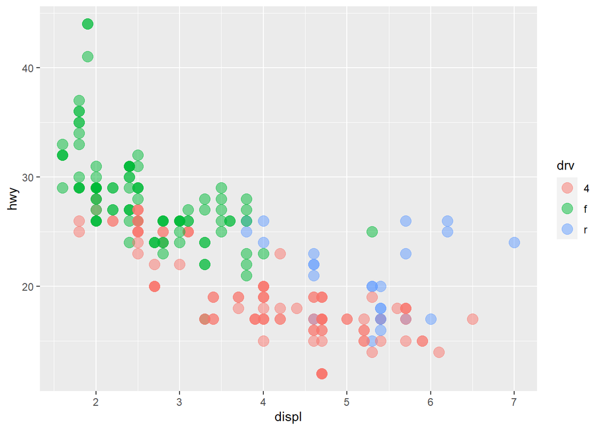

```r
g+geom_point(size = 4, alpha = 0.5,aes(color = drv))
```

##### Explanation:

**Note that you MUST use** the function **aes** since **the color of the points is data dependent** and not a constant as it was in the previous example.

- Notice the helpful legend on the right decoding the relationship between color and drv.

#### 3.3.3 Customizing labels

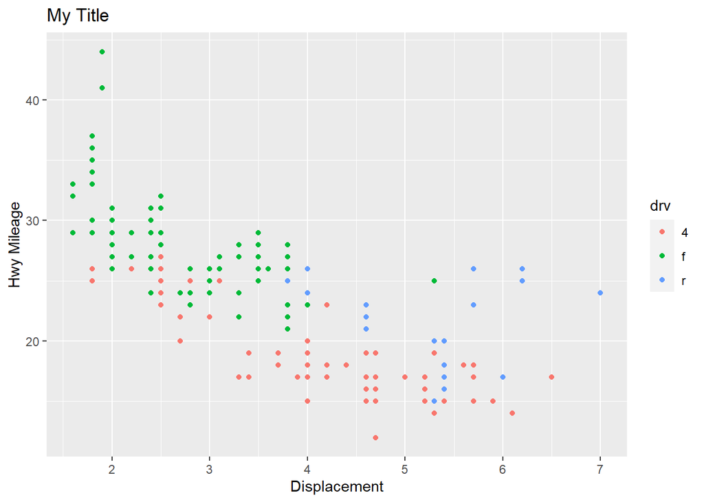

```r
g+geom_point(aes(color = drv))+labs(title = "My Title")+labs(x="Displacement",y="Hwy Mileage")
```

##### Explanation:

- Note that you could have combined the two calls to the function labs in the previous example.

#### 3.3.4 customizing geom_smooth()

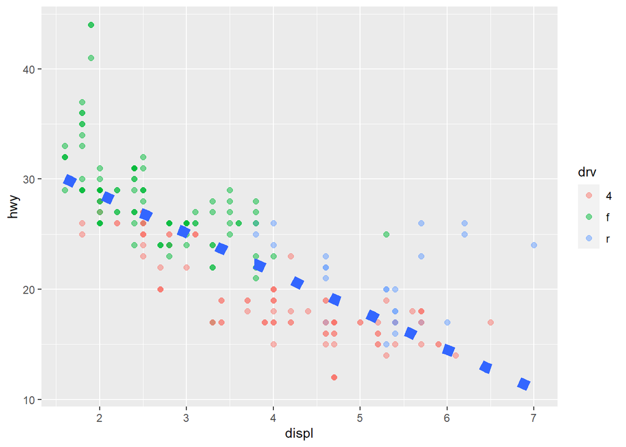

```r
g+geom_point(aes(color = drv),size = 2, alpha = 0.5)+geom_smooth(size = 4, linetype = 3, method = "lm", se = FALSE)
```

##### Explanation:

- The **method specified a linear regression** (note the negative slope indicating that the bigger the displacement the lower the gas mileage), - the **linetype specified that it should be dashed** (not continuous), - the **size made the dashes big**, and
- the **se flag told ggplot to turn off the gray shadows indicating standard errors** (confidence intervals).

### 3.4 plot using the black and white theme, theme_bw

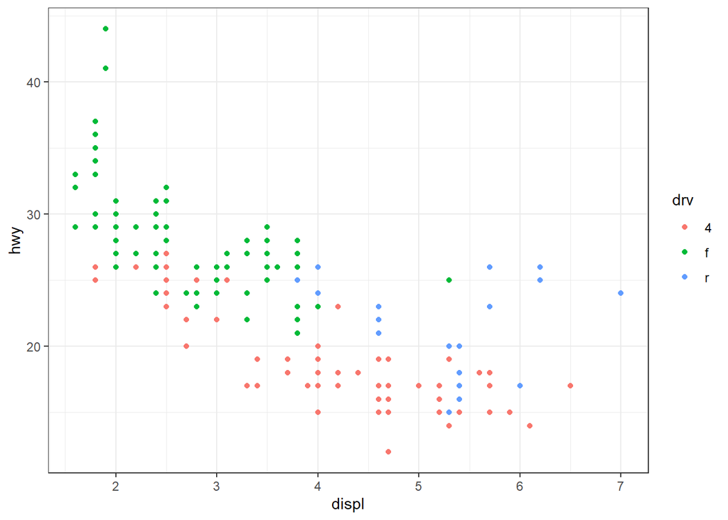

```r
g+geom_point(aes(color = drv))+theme_bw(base_family = "Times")
```

##### Explanation:

- No more gray background!
- the font in the labels changed.

### 3.5 impulse handling

##### What is impulse

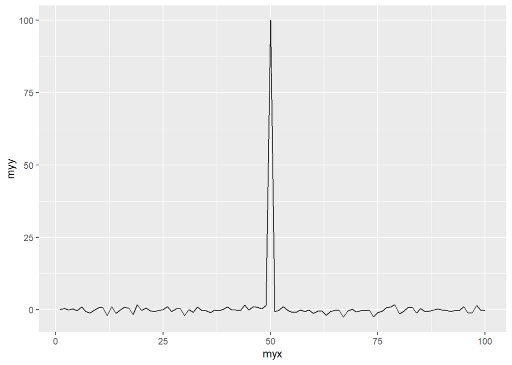

```r
testdat <- data.frame(myx = 1:100, myy = rnorm(100))
testdat[50,2] <- 100 ## Outlier!

g <- ggplot(testdat, aes(x = myx, y = myy))
g+geom_line()
```

##### How it handled by base plot

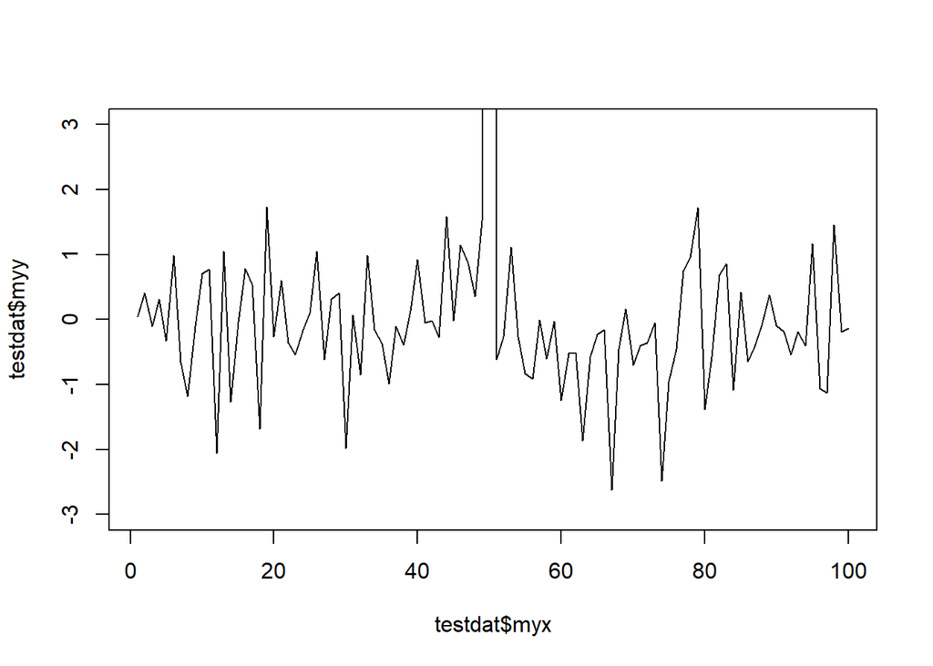

```r
plot(testdat$myx, testdat$myy, type = "l", ylim = c(-3,3))
```

##### if we code just like base plot

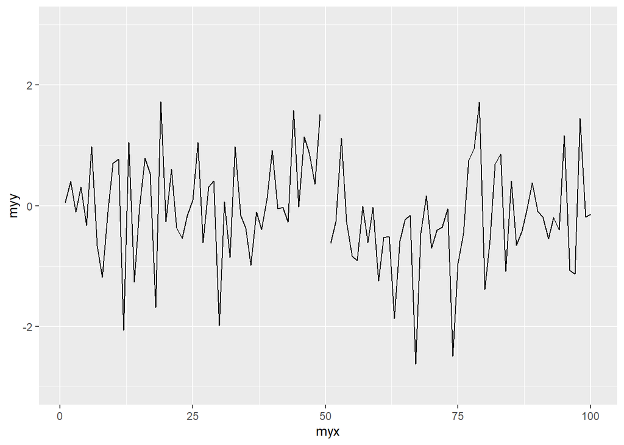

```r
g+geom_line()+ylim(-3,3)
```

##### coordinate system will give expected result

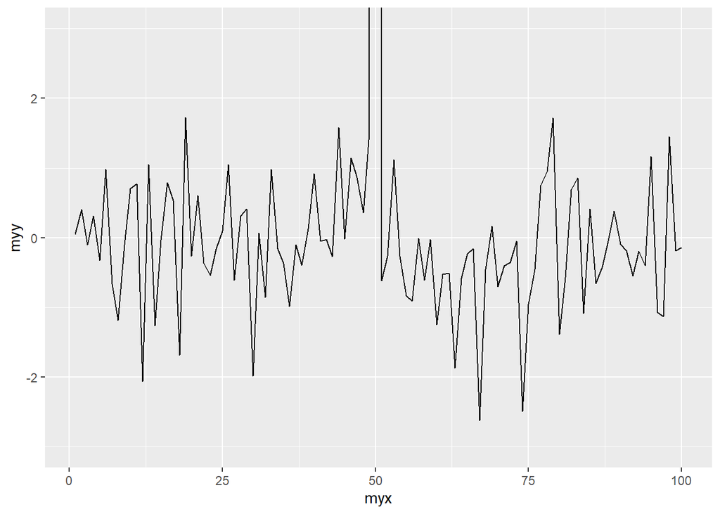

```r
g+geom_line()+coord_cartesian(ylim=c(-3,3))
```

##### EXplanation:

- This looks more like the plot produced by the base plot function.
- The outlier y value at x=50 is not shown, but the plot indicates that it is larger than 3.

### 3.6 Complicated example presentation using ggplot

##### Plot for displ Vs hwy along with distinguish between the two manufacturing years (1999 and 2008)

```r
g <- ggplot(mpg, aes(x = displ,y = hwy, color = factor(year)))
```

##### Show Plot

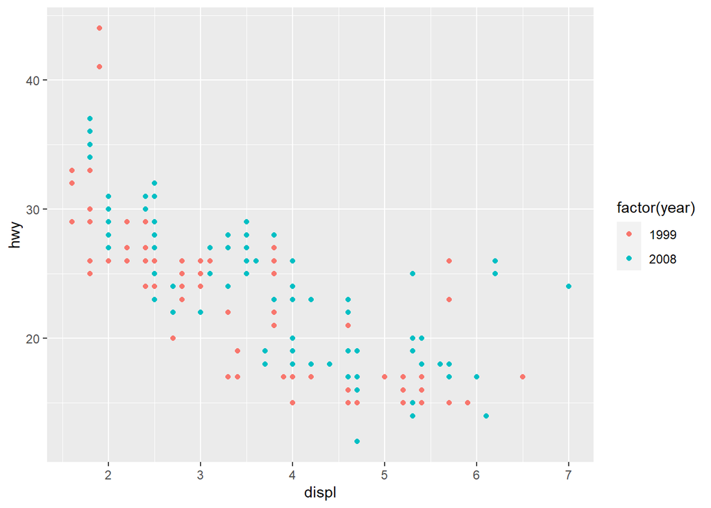

```r
g+geom_point()
```

##### Let’s make our display a 2 dimensional multi-panel plot.

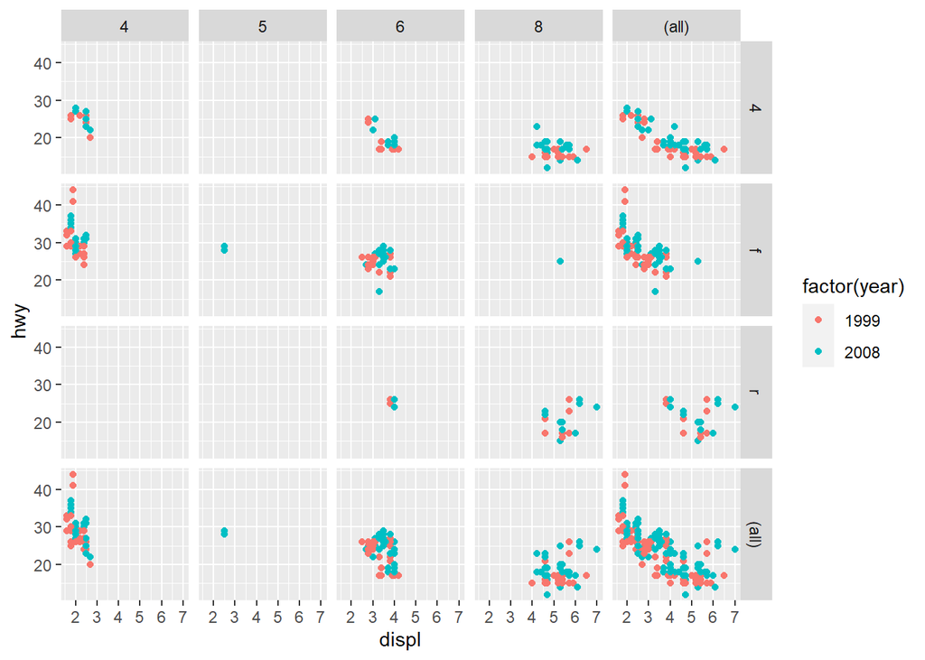

```r
g+geom_point()+facet_grid(drv~cyl,margins = TRUE)
```

##### EXplanation:

- A 4 by 5 plot,
- The **margins argument** tells ggplot to **display the marginal totals over each row and column**,
  - so instead of seeing 3 rows (the number of drv factors) and 4 columns (the number of cyl factors) we see a 4 by 5 display.
- Note that the **panel in position (4,5) is a tiny version of the scatterplot of the entire dataset**.

##### Adding Regression line to all plots along with common labels

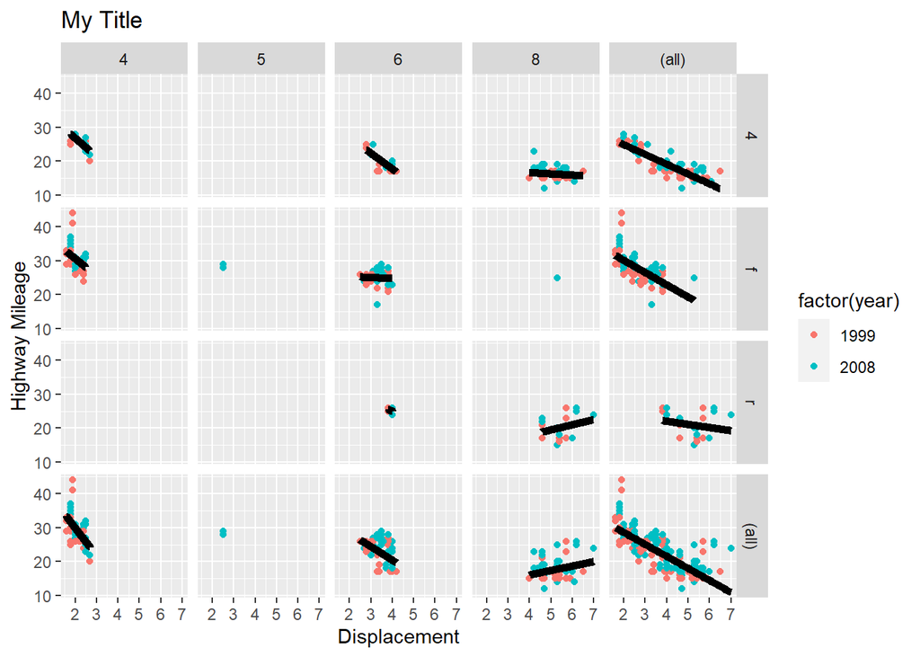

```r
g+geom_point()+facet_grid(drv~cyl,margins = TRUE)+geom_smooth(method = "lm", se = FALSE, size = 2, color = "black")+ labs(x = "Displacement", y = "Highway Mileage",title = "My Title")
```